# Lab 3

Mia Dawson, GEO200CN, Spring 2017

## Instructions

**1) Carefully read Chapter 2 of the R Spatial R companion to Geographic Information Analysis http://rspatial.org/rosu/rst/Chapter2.html** . Answer the six questions found in the text, and hand in the results as a R Markdown file. Upload both the source file and a HTML file.

# Results

## Modifiable Areal Unit Problem

```r
# independent variable
ind <- c(87, 95, 72, 37, 44, 24,
         40, 55, 55, 38, 88, 34,
         41, 30, 26, 35, 38, 24,
         14, 56, 37, 34,  8, 18,
         49, 44, 51, 67, 17, 37,
         55, 25, 33, 32, 59, 54)

# dependent variable
dep <- c(72, 75, 85, 29, 58, 30,
         50, 60, 49, 46, 84, 23,
         21, 46, 22, 42, 45, 14,
         19, 36, 48, 23,  8, 29,
         38, 47, 52, 52, 22, 48,
         58, 40, 46, 38, 35, 55)
plot(ind, dep)
m <- glm(dep ~ ind)
m
```

```
##
## Call:  glm(formula = dep ~ ind)
##
## Coefficients:
## (Intercept)          ind
##     10.3750       0.7543
##
## Degrees of Freedom: 35 Total (i.e. Null);  34 Residual
## Null Deviance:       12080
## Residual Deviance: 3742  AIC: 275.3
```

```r
s=summary(m)
s
```

```
##
## Call:
## glm(formula = dep ~ ind)
##
## Deviance Residuals:
##     Min       1Q   Median       3Q      Max
## -20.303   -8.536    3.293    7.466   20.312
##
## Coefficients:
##             Estimate Std. Error t value Pr(>|t|)
## (Intercept) 10.37497    4.12773   2.513   0.0169 *
## ind          0.75435    0.08668   8.703 3.61e-10 ***
## ---
## Signif. codes:  0 '***' 0.001 '**' 0.01 '*' 0.05 '.' 0.1 ' ' 1
##
## (Dispersion parameter for gaussian family taken to be 110.0631)
##
##     Null deviance: 12078.8  on 35  degrees of freedom
## Residual deviance:  3742.1  on 34  degrees of freedom
## AIC: 275.34
##
## Number of Fisher Scoring iterations: 2
```

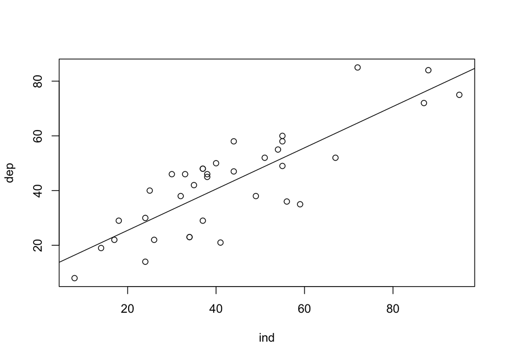

```r
plot(ind, dep)
abline(m)
```

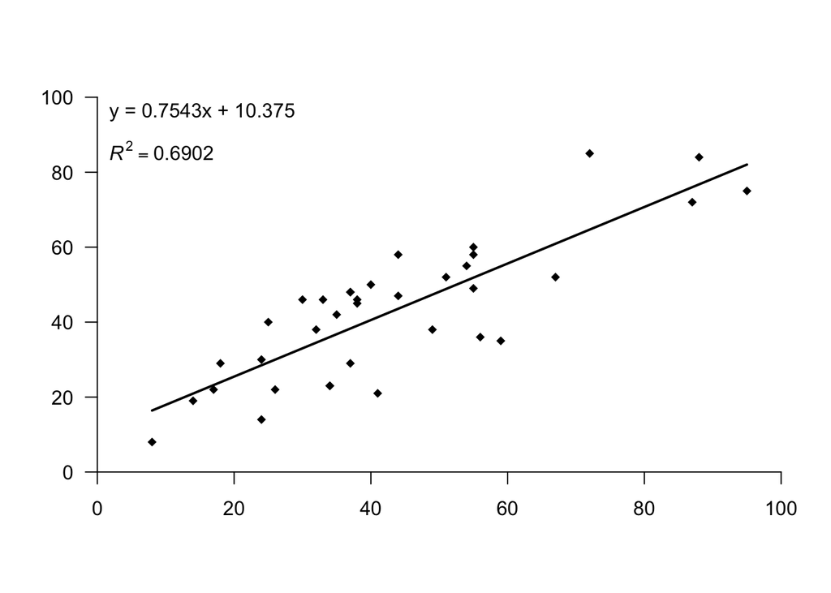

```r
plot(ind, dep, pch=18, xlim=c(0,100), ylim=c(0,100),
    axes=FALSE, xlab='', ylab='', yaxs="i", xaxs="i")
axis(1, at=(0:5)*20)
axis(2, at=(0:5)*20, las=1)

# create regression formula
f <- paste0('y = ', round(s$coefficients[2], 4), 'x + ', round(s$coefficients[1], 4))
# add the text in variable f to the plot
text(0, 96, f, pos=4)
# compute r-squared
R2 <- cor(dep, predict(m))^2

# set up the expression (a bit complex, this)
r2 <- bquote(italic(R)^2 == .(round(R2, 4)))
# and add it to the plot
text(0, 85, r2, pos=4)

# compute regression line
# create a data.frame with the range (minimum and maximum) of values of ind
px <- data.frame(ind = range(ind))
# use the regression model to get predicted value for dep at these two extremes
py <- predict(m, px)
# combine the min and max values and the predicted values
ln <- cbind(px, py)
# add to the plot as a line
lines(ln, lwd=2)
```

### Question 1: Create these matrices from ind and dep without using byrow=TRUE. Hint: use the t function after you made the matrix.

```r
mi <- matrix(ind, ncol=6, nrow=6, byrow=TRUE)
md <- matrix(dep, ncol=6, nrow=6, byrow=TRUE)

mi2  <- matrix(ind, ncol=6, nrow=6)
md2 <- matrix(dep, ncol=6, nrow=6)

#without using byrow=TRUE, default is byrow = false, so I transpose the matrices here
mi2 = t(mi2)
md2 = t(md2)
```

Begin working with raster data

```r
# load package
library(raster)
## Loading required package: sp

# turn matrices into RasterLayer objects
ri <- raster(mi)
rd <- raster(md)
ri
```

```
## class       : RasterLayer
## dimensions  : 6, 6, 36  (nrow, ncol, ncell)
## resolution  : 0.1666667, 0.1666667  (x, y)
## extent      : 0, 1, 0, 1  (xmin, xmax, ymin, ymax)
## coord. ref. : NA
## data source : in memory
## names       : layer
## values      : 8, 95  (min, max)
```

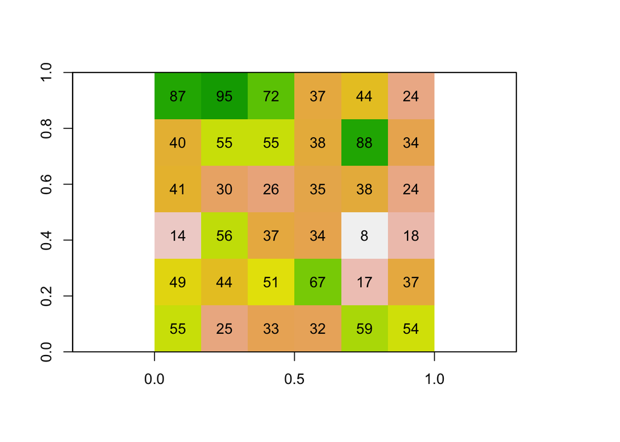

```r
plot(ri, legend=FALSE)
text(ri)
```

```r
ai1 <- aggregate(ri, c(2, 1), fun=mean)
ad1 <- aggregate(rd, c(2, 1), fun=mean)
as.matrix(ai1)
```

```
##      [,1] [,2] [,3]
## [1,] 91.0 54.5 34.0
## [2,] 47.5 46.5 61.0
## [3,] 35.5 30.5 31.0
## [4,] 35.0 35.5 13.0
## [5,] 46.5 59.0 27.0
## [6,] 40.0 32.5 56.5
```

```r
as.matrix(ad1)
```

```
##      [,1] [,2] [,3]
## [1,] 73.5 57.0 44.0
## [2,] 55.0 47.5 53.5
## [3,] 33.5 32.0 29.5
## [4,] 27.5 35.5 18.5
## [5,] 42.5 52.0 35.0
## [6,] 49.0 42.0 45.0
```

### Question 2: Instead of the mean function What other functions could, in principle, reasonably be used in an aggregation of raster cells?

In principle, other functions to use instead of mean would be modal, min, max, and sum.

Stacking rasters

```r
s1 <- stack(ai1, ad1)
names(s1) <- c('ind', 'dep')
s1
```

```
## class       : RasterStack
## dimensions  : 6, 3, 18, 2  (nrow, ncol, ncell, nlayers)
## resolution  : 0.3333333, 0.1666667  (x, y)
## extent      : 0, 1, 0, 1  (xmin, xmax, ymin, ymax)
## coord. ref. : NA
## names       :  ind,  dep
## min values  : 13.0, 18.5
## max values  : 91.0, 73.5
```

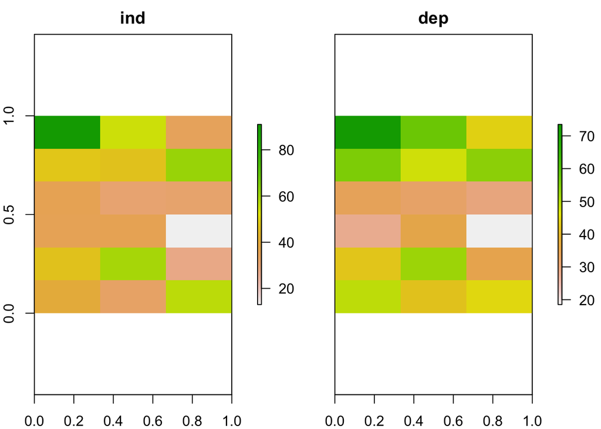

```r
## class       : RasterStack
## dimensions  : 6, 3, 18, 2  (nrow, ncol, ncell, nlayers)
## resolution  : 0.3333333, 0.1666667  (x, y)
## extent      : 0, 1, 0, 1  (xmin, xmax, ymin, ymax)
## coord. ref. : NA
## names       :  ind,  dep
## min values  : 13.0, 18.5
## max values  : 91.0, 73.5
plot(s1)
```

Coerce RasterStack into a data.frame

```r
d1 <- as.data.frame(s1)
head(d1)
```

```
##    ind  dep
## 1 91.0 73.5
## 2 54.5 57.0
## 3 34.0 44.0
## 4 47.5 55.0
## 5 46.5 47.5
## 6 61.0 53.5
```

### Question 3: There are other ways to do the above (converting two RasterLayer objects to a data.frame). Show how to obtain the same result (d1) using as.vector and cbind.

```r
vi = as.vector(ai1)
vd = as.vector(ad1)
d2 = cbind(vi, vd)
colnames(d2) = c("ind", "dep")
head(d2)
```

```
##       ind  dep
## [1,] 91.0 73.5
## [2,] 54.5 57.0
## [3,] 34.0 44.0
## [4,] 47.5 55.0
## [5,] 46.5 47.5
## [6,] 61.0 53.5
```

```r
d2 = as.data.frame(d2)
head(d2)
```

```
##    ind  dep
## 1 91.0 73.5
## 2 54.5 57.0
## 3 34.0 44.0
## 4 47.5 55.0
## 5 46.5 47.5
## 6 61.0 53.5
```

## Distance, adjacency, interaction, and neighborhood

Set up data

```r
A <- c(40, 43)
B <- c(1, 101)
C <- c(54, 111)
D <- c(104, 65)
E <- c(60, 22)
F <- c(20, 2)
pts <- rbind(A,B,C,D,E,F)
head(pts)
```

```
##   [,1] [,2]
## A   40   43
## B    1  101
## C   54  111
## D  104   65
## E   60   22
## F   20    2
```

Plot points

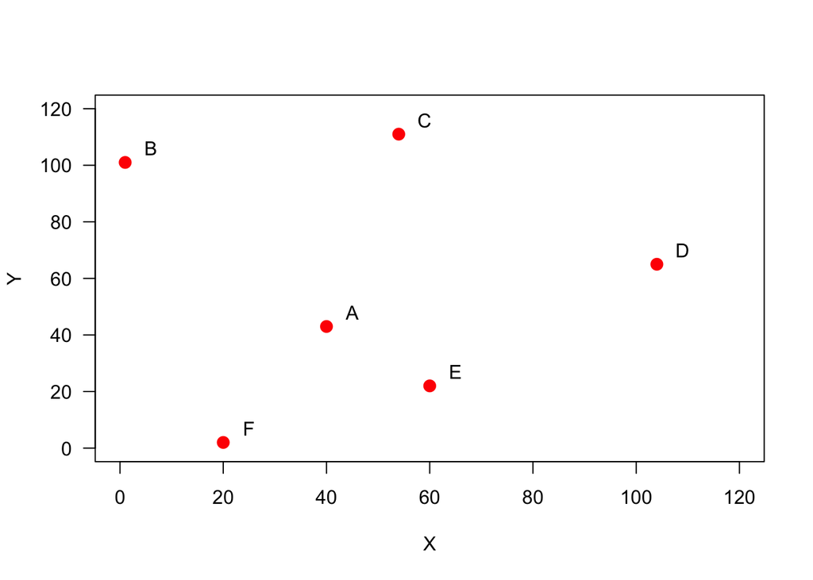

```r
plot(pts, xlim=c(0,120), ylim=c(0,120), pch=20, cex=2, col='red', xlab='X', ylab='Y', las=1)
text(pts+5, LETTERS[1:6])
```

Make a distance matrix

```r
dis <- dist(pts)
dis
```

```
##           A         B         C         D         E
## B  69.89278
## C  69.42622  53.93515
## D  67.67570 109.11004  67.94115
## E  29.00000  98.60020  89.20202  61.52235
## F  45.61798 100.80675 114.17968 105.00000  44.72136
```

```r
D <- as.matrix(dis)
round(D)
```

```
##    A   B   C   D  E   F
## A  0  70  69  68 29  46
## B 70   0  54 109 99 101
## C 69  54   0  68 89 114
## D 68 109  68   0 62 105
## E 29  99  89  62  0  45
## F 46 101 114 105 45   0
```

### Question 4: Show R code to make a cluster dendogram summarizing the distances between these six sites, and plot it.

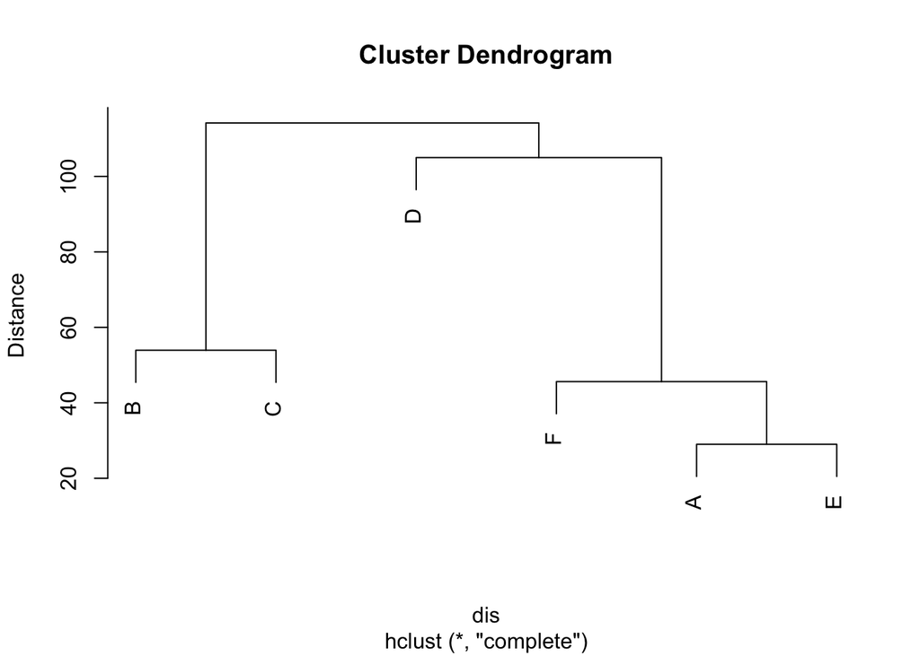

```r
dendo=hclust(dis)
plot(dendo, ylab = "Distance", xlab=NULL)
```

Distance based adjacency

```r
a <-  D < 50
a
```

```
##       A     B     C     D     E     F
## A  TRUE FALSE FALSE FALSE  TRUE  TRUE
## B FALSE  TRUE FALSE FALSE FALSE FALSE
## C FALSE FALSE  TRUE FALSE FALSE FALSE
## D FALSE FALSE FALSE  TRUE FALSE FALSE
## E  TRUE FALSE FALSE FALSE  TRUE  TRUE
## F  TRUE FALSE FALSE FALSE  TRUE  TRUE
```

```r
diag(a) <- NA #set diagonal values to NA
Ad50 <- a * 1 #change TRUE/FLASE to 1/0
Ad50
```

```
##    A  B  C  D  E  F
## A NA  0  0  0  1  1
## B  0 NA  0  0  0  0
## C  0  0 NA  0  0  0
## D  0  0  0 NA  0  0
## E  1  0  0  0 NA  1
## F  1  0  0  0  1 NA
```

Nearest neighbours

```r
cols <- apply(D, 1, order) # get the column numbers in order of the values in that row (that is, the numbers indicate how the values are ordered)
# we need to transpose the result
cols <- t(cols)
cols = cols[ , 2:4]
cols
```

```
##   [,1] [,2] [,3]
## A    5    6    4
## B    3    1    5
## C    2    4    1
## D    5    1    3
## E    1    6    4
## F    5    1    2
```

```r
#make row column pairs
rowcols <- cbind(rep(1:6, each=3), as.vector(t(cols)))
head(rowcols)
```

```
##      [,1] [,2]
## [1,]    1    5
## [2,]    1    6
## [3,]    1    4
## [4,]    2    3
## [5,]    2    1
## [6,]    2    5
```

```r
#use these pairs as indices to change the values in matrix Ak3
Ak3 <- Ad50 * 0
Ak3[rowcols] <- 1
Ak3
```

```
##    A  B  C  D  E  F
## A NA  0  0  1  1  1
## B  1 NA  1  0  1  0
## C  1  1 NA  1  0  0
## D  1  0  1 NA  1  0
## E  1  0  0  1 NA  1
## F  1  1  0  0  1 NA
```

Weights matrix

```r
#get weight matrix
W <- 1 / D
round(W, 4)
```

```
##        A      B      C      D      E      F
## A    Inf 0.0143 0.0144 0.0148 0.0345 0.0219
## B 0.0143    Inf 0.0185 0.0092 0.0101 0.0099
## C 0.0144 0.0185    Inf 0.0147 0.0112 0.0088
## D 0.0148 0.0092 0.0147    Inf 0.0163 0.0095
## E 0.0345 0.0101 0.0112 0.0163    Inf 0.0224
## F 0.0219 0.0099 0.0088 0.0095 0.0224    Inf
```

```r
#Row-normalization is not that difficult either. First get rid if the Inf values by changing them to NA. (Where did the Inf values come from?)
W[!is.finite(W)] <- NA

#compute row sums
rtot <- rowSums(W, na.rm=TRUE)
# this is equivalent to
# rtot <- apply(W, 1, sum, na.rm=TRUE)
rtot
```

```
##          A          B          C          D          E          F
## 0.09989170 0.06207541 0.06763182 0.06443810 0.09445017 0.07248377
```

```r
W <- W / rtot
rowSums(W, na.rm=TRUE) #Divide the rows by their totals and check if they row sums add up to 1
```

```
## A B C D E F
## 1 1 1 1 1 1
```

### Question 5: Show how you can do ‘column-normalization’ (Just an exercise, in spatial data analysis this is not a typical thing to do).

```r
W2 <- t(W) #transpose W for column normalization
round(W2, 4)
```

```
##        A      B      C      D      E      F
## A     NA 0.2305 0.2130 0.2293 0.3651 0.3024
## B 0.1432     NA 0.2741 0.1422 0.1074 0.1369
## C 0.1442 0.2987     NA 0.2284 0.1187 0.1208
## D 0.1479 0.1476 0.2176     NA 0.1721 0.1314
## E 0.3452 0.1634 0.1658 0.2522     NA 0.3085
## F 0.2194 0.1598 0.1295 0.1478 0.2367     NA
```

```r
W2[!is.finite(W2)] <- NA
coltot = colSums(W2, na.rm=TRUE)
coltot
```

```
## A B C D E F
## 1 1 1 1 1 1
```

## Proximity polygons

Load packages and use voronoi command to previously used points

```r
#install.packages('dismo')
#install.packages('deldir')
library(dismo)
library(deldir)
v <- voronoi(pts)
```

Make Voronoi diagram

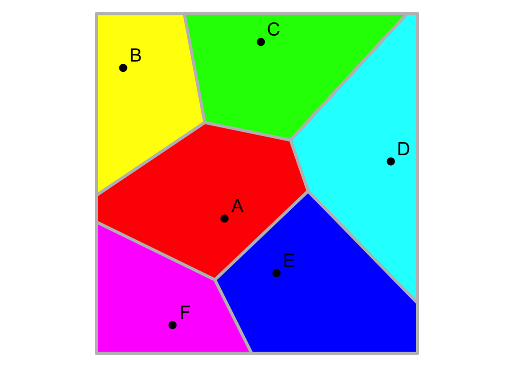

```r
par(mai=rep(0,4))
plot(v, lwd=4, border='gray', col=rainbow(6))
points(pts, pch=20, cex=2)
text(pts+5, toupper(letters[1:6]), cex=1.5)
```

### Question 6. The SpatialPolygonDataFrame class is defined in package sp. But we never used library(‘sp’) . So how is it possible that we have one of such objects?

When we loaded the raster package, it also loaded the sp package. The sp package is required for the functionality of the raster package.